# 04 二分类问题

2026-10-3

课程代码均在如下 GitHub 仓库开源：https://github.com/GHe0000/xmu_machine_learning

项目自动生成网页地址：https://ghe0000.github.io/xmu_machine_learning

## 目录

- 作业要求
- 背景补充
  - Logistic 回归与 BCE
  - 二分类评价指标
- 数据集生成和划分
  - 计算准备
  - 数据生成
  - 数据划分
- 特征选取和特征标准化
- 模型训练
  - BCE 损失函数定义
  - 梯度下降
  - 模型训练过程
  - 分类边界
  - 学习率调优
  - 多项式阶数调优
- 模型评估
  - 混淆矩阵
  - Accuracy、Precision、Recall、F1
- MSE 和 BCE 对比
  - MSE 下的训练及调优
  - 对比分析
  - 理论解释
- 随机权重初始化对结果的影响
  - BCE 下随机权重影响
  - MSE 下随机权重影响
  - 理论解释
- 结论
- 参考资料以及 AI 使用说明
- 致谢
- 附一：问题
- 附二：学习心得

## 作业要求

在如下数据集上做 logistic 回归

```
import numpy as np
import matplotlib.pyplot as plt
from sklearn.datasets import make_moons, make_blobs, make_circles, make_classification

X,y = make_moons(n_samples=220,noise= 0.18,random_state=44) #线性不可分数据集

m = X.shape[0] # 样本数 220

plt.plot(X[np.where(y == 1),0],X[(np.where(y == 1)),1],'ro'); #(x1,x2) for y=1
plt.plot(X[np.where(y == 0),0],X[(np.where(y == 0)),1],'bo'); #(x1,x2) for y=0

plt.xlabel(r"$x_1$");
plt.ylabel(r"$x_2$");
plt.title("make moons data set");
plt.grid(True);
```

要求：

- 完整的机器学习流程
- 对比平方误差 loss 和交叉熵 loss 的效果
- 讨论随机权重初始化对结果的影响（可选）

## 背景补充

### Logistic 回归与 BCE

对于二分类问题, 目标变量只有两个取值

$$ y\in\{0,1\} $$

Logistic 回归首先计算特征的线性组合

$$ z=\mathbf w^\mathsf T\mathbf x+b $$

再通过 Sigmoid 函数

$$ \sigma(z)=\frac{1}{1+e^{-z}} $$

将其映射到 $(0,1)$ 区间

$$ \hat y= \sigma(\mathbf w^\mathsf T\mathbf x+b) $$

因此可以将模型输出解释为条件概率

$$ \hat y=P(Y=1\mid\mathbf x) $$

相应地

$$ P(Y=0\mid\mathbf x)=1-\hat y $$

对于 $m$ 个独立样本, 总似然函数为

$$ L(\mathbf w,b)= \prod_{i=1}^{m} \hat y_i^{y_i} (1-\hat y_i)^{1-y_i} $$

训练 Logistic 回归时采用最大似然估计, 即寻找参数使真实训练数据出现的概率最大. 最大化似然等价于最小化负对数似然

$$ -\ln L= -\sum_{i=1}^{m} \left[ y_i\ln\hat y_i + (1-y_i)\ln(1-\hat y_i) \right] $$

对样本取平均后得到 Binary Cross Entropy, BCE

$$ J_{\mathrm{BCE}}= -\frac1m \sum_{i=1}^{m} \left[ y_i\ln\hat y_i + (1-y_i)\ln(1-\hat y_i) \right] $$

当 BCE 与 Sigmoid 结合时, 对线性输出 $z$ 求导可以得到

$$ \frac{\partial J_{\mathrm{BCE}}}{\partial z}= \hat y-y $$

### 二分类评价指标

对于二分类问题, 将类别 $1$ 定义为正类 Positive, 类别 $0$ 定义为负类 Negative.

根据真实类别和预测类别, 样本可以分成四种情况：

$$ TP:\quad y=1,\ \tilde y=1 $$

$$ TN:\quad y=0,\ \tilde y=0 $$

$$ FP:\quad y=0,\ \tilde y=1 $$

$$ FN:\quad y=1,\ \tilde y=0 $$

对应的混淆矩阵为

$$ C= \begin{pmatrix} TN&FP\\ FN&TP \end{pmatrix} $$

Accuracy 表示所有样本中预测正确的比例

$$ \mathrm{Accuracy}= \frac{TP+TN} {TP+TN+FP+FN} $$

Accuracy 描述模型整体分类正确的程度. 但在类别严重不平衡时, 仅使用 Accuracy 可能产生误导.

Precision 表示所有被模型预测为正类的样本中, 实际属于正类的比例

$$ \mathrm{Precision}= \frac{TP}{TP+FP} $$

因此 Precision 主要衡量正类预测的可靠程度. Precision 越高, False Positive 越少.

Recall 表示所有真实正类样本中, 被模型成功识别出来的比例

$$ \mathrm{Recall}= \frac{TP}{TP+FN} $$

因此 Recall 主要衡量模型是否遗漏真实正类. Recall 越高, False Negative 越少.

Precision 和 Recall 分别关注两种不同的分类错误. 为综合考虑二者, 定义 F1 为二者的调和平均

$$ F_1= \frac{ 2\,\mathrm{Precision}\,\mathrm{Recall} }{ \mathrm{Precision}+\mathrm{Recall} } $$

只有当 Precision 和 Recall 同时较高时, F1 才会取得较高数值.

## 数据集生成和划分

### 计算准备

导入需要的库，并针对 Jupyter Notebook 进行一些设置.

### 数据生成

根据题目所给代码，生成数据集，并进行可视化.

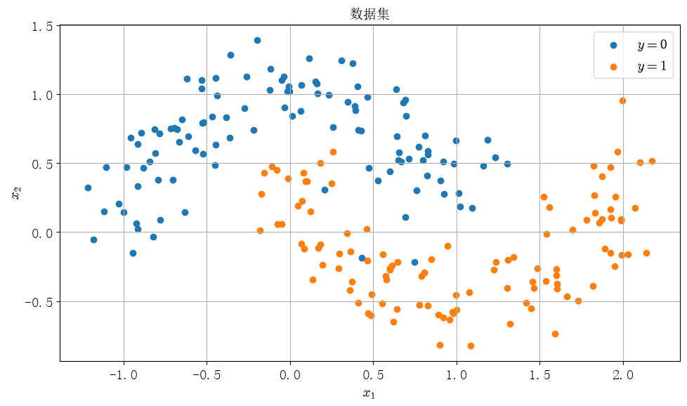

可见，这里的分类边界不是一条直线，因此我们需要使用高阶特征，否则分类效果不好.

### 数据划分

按 6:2:2 划分训练、验证、测试三个集合.

```
训练集： (132, 2)
验证集： (44, 2)
测试集： (44, 2)
```

绘制分类后的数据集：

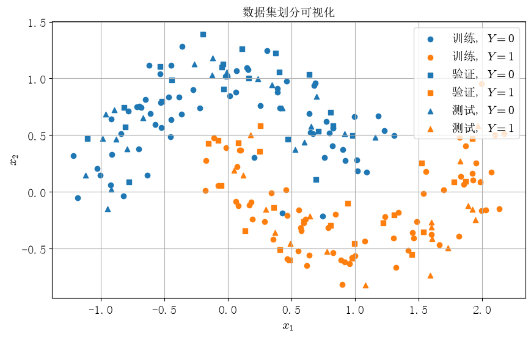

## 特征选取和特征标准化

从图中可以看见，分类边界非线性，因此引入 $x_1,x_2$ 的多项式特征. 对于最高阶数 $p$，选取所有满足

$$ 1\le a+b\le p $$

的单项式 $x_1^a x_2^b$ 作为新的输入特征. 后续通过改变 $p$ 来控制模型的复杂度，并比较不同阶数下模型在验证集上的表现. 本节先取 $p=2$ 作为初始模型.

多项式特征的数值尺度可能存在较大差异. 如果直接使用这些特征进行梯度下降，不同特征对应的参数可能具有不同的更新尺度，从而影响优化的稳定性和收敛速度.

因此，对每一个特征分别进行标准化：

$$ \tilde\phi_j=\frac{\phi_j-\mu_j}{\sigma_j} $$

## 模型训练

### BCE 损失函数定义

对于 Logistic 回归，模型输出为

$$ \hat y_i=\sigma(\mathbf w^\mathsf T\mathbf x_i+b) $$

训练时使用二元交叉熵损失函数

$$ J_{\mathrm{BCE}}=-\frac{1}{m} \sum_{i=1}^{m} \left[y_i\ln\hat y_i+(1-y_i)\ln(1-\hat y_i)\right] $$

### 梯度下降

BCE 对应的参数梯度为

$$ \nabla_{\mathbf w}J_{\mathrm{BCE}}=\frac{1}{m}X^\mathsf T(\hat{\mathbf y}-\mathbf y) $$

$$ \frac{\partial J_{\mathrm{BCE}}}{\partial b}=\frac{1}{m}\sum_{i=1}^{m}(\hat y_i-y_i) $$

使用梯度下降更新参数：

$$ \mathbf w \leftarrow \mathbf w - \eta\nabla_{\mathbf w}J_{\mathrm{BCE}} $$

$$ b \leftarrow b-\eta\frac{\partial J_{\mathrm{BCE}}}{\partial b} $$

其中 $\eta$ 为学习率.

本节暂时使用随机初始化的权重，学习率取 $\eta=0.1$ 训练轮数 $ N_{\mathrm{epoch}}=2000$. 每一轮使用 Val 进行验证，保存并返回训练过程中 Val Loss 最小的权重.

### 模型训练过程

绘制 Train loss 和 Val loss 随 Epoch 的变化

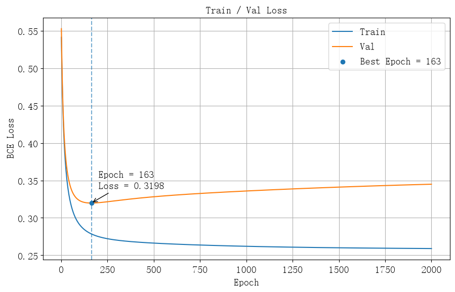

可见，模型 Train Loss 一直下降，Val Loss 先降后升，在 Epoch=163 时最小，呈现标准的“欠学习”到"过学习"的过程.

我们取 Val Loss 最小的作为我们取权重的标准.

### 分类边界

我们进一步画出此时模型的分类边界：

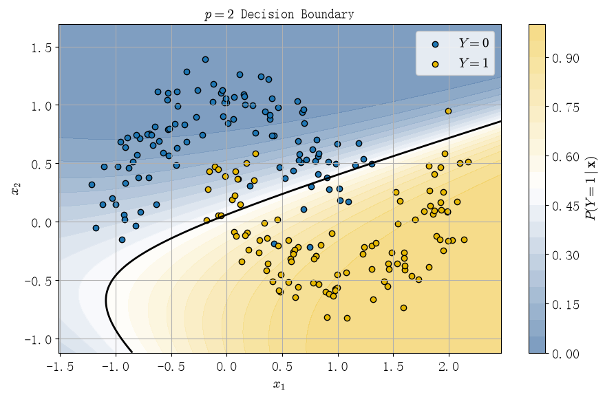

可见，此时模型大体上可以分类，基本的训练过程没有问题.

但分类边界和数据集仍旧有偏差，我们估计是因为多项式阶数太小导致的. 下面我们改变相关超参，观察优化效果变化.

### 学习率调优

首先，我们改变学习率，取最大轮数 $N=2000$ 下，改变学习率 $\eta$ 从 $10^{-4}$ 到 $1$. 观察 2000 论中最优模型的 Loss 随学习率的变化.

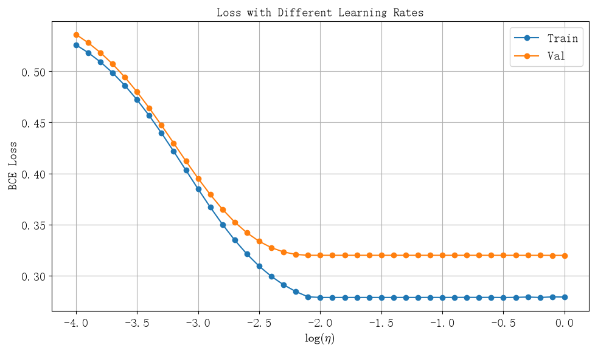

可以看见，学习率在 $0.01-1$ 之间最后的 Loss 没有明显变化. 当学习率低于 $0.01$ 时，由于训练轮数不够，因此没有收敛到最优值.

平衡收敛速度和最后精度，之后统一取学习率 $\eta=1$.

### 多项式阶数调优

对于多项式阶数，在最大轮数 $2000$ 学习率 $1$ 下，扫描 $1$ 阶到 $10$ 阶，并绘制训练过程中最优 Val Loss 下的模型的 Loss.

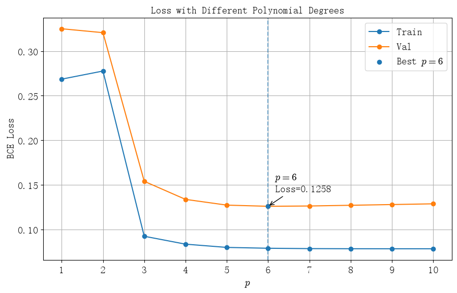

从图中可以看到, 随着多项式阶数 $p$ 增大, Train Loss 在 $p=1\to2$ 时略有上升, 随后总体下降. Val Loss 则先明显下降, 并在 $p=6$ 时取得最小值.

当继续增加 $p$ 时, Train Loss 仍缓慢下降, 而 Val Loss 开始小幅上升, 表明模型开始出现轻微过拟合. 因此最终选择 $p=6$ 作为最优多项式阶数.

进一步绘制此时的分类边界，有：

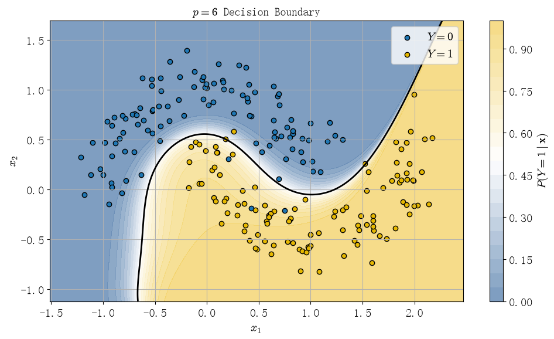

可见，此时模型的分类边界和数据集趋势基本相符，少量的噪声并没有明显影响分类边界. 模型是比较准确的.

## 模型评估

### 混淆矩阵

对于二分类问题, 根据真实类别与预测类别之间的关系, 可以将测试样本分为四类.

$$ TP:\quad y=1,\ \tilde y=1 $$

表示实际为正类, 同时正确预测为正类.

$$ TN:\quad y=0,\ \tilde y=0 $$

表示实际为负类, 同时正确预测为负类.

$$ FP:\quad y=0,\ \tilde y=1 $$

表示实际为负类, 但错误预测为正类.

$$ FN:\quad y=1,\ \tilde y=0 $$

表示实际为正类, 但错误预测为负类.

将四种情况写成混淆矩阵

$$ C=\begin{pmatrix} TN & FP\\ FN & TP \end{pmatrix} $$

其中主对角线表示分类正确的样本, 非对角线表示分类错误的样本.

下面我们进一步评估我们训练得到的最优模型. 我们在测试集上计算混淆矩阵. 如下：

```
TN = 22
FP = 0
FN = 1
TP = 21
```

绘制结果，如下：

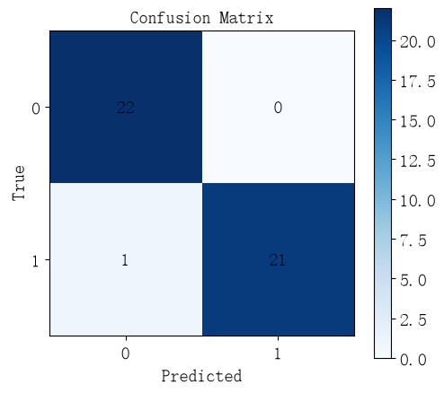

可见此时模型在 Test 集合中有且只有一个预测错误的情况.

我们可以在 Train Test Val 和全数据集中绘制混淆矩阵，如下：

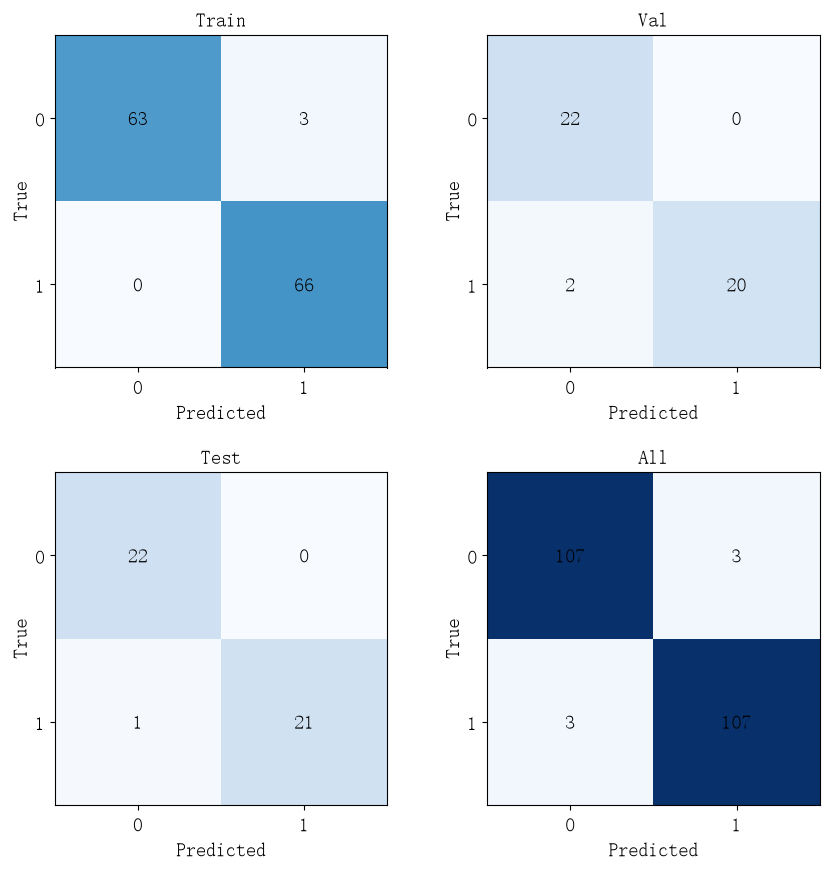

从混淆矩阵可以看出, 模型在各数据集上均具有较好的分类效果. Train 中有 3 个负类样本被误判为正类, Val 中有 2 个正类样本被误判为负类, Test 中有 1 个正类样本被误判为负类.

在全部 220 个样本中共有 6 个样本分类错误, 其中 $FP=3$, $FN=3$, 整体分类正确率约为

$$ \mathrm{Accuracy}=97.27\% $$

说明最终模型在当前数据划分下具有较好的分类性能.

### Accuracy、Precision、Recall、F1

进一步根据四个混淆矩阵计算 Accuracy、Precision、Recall 和 F1.

$$ \mathrm{Accuracy}= \frac{TP+TN}{TP+TN+FP+FN} $$

$$ \mathrm{Precision}= \frac{TP}{TP+FP} $$

$$ \mathrm{Recall}= \frac{TP}{TP+FN} $$

$$ F_1= \frac{2TP}{2TP+FP+FN} $$

分别对 Train、Val、Test 和 All 计算这些指标, 可以进一步比较模型在不同数据集上的分类性能.

|  | Accuracy | Precision | Recall | F1 |
| --- | --- | --- | --- | --- |
| Train | 0.977273 | 0.956522 | 1.000000 | 0.977778 |
| Val | 0.954545 | 1.000000 | 0.909091 | 0.952381 |
| Test | 0.977273 | 1.000000 | 0.954545 | 0.976744 |
| All | 0.972727 | 0.972727 | 0.972727 | 0.972727 |

绘制成柱状图，为：

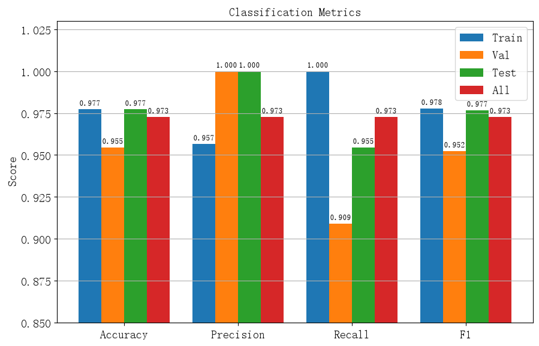

四组数据的 Accuracy、Precision、Recall 和 F1 均保持在较高水平.

Train 中 Recall 为 $1$, 表明所有正类训练样本均被正确识别, 但有 3 个负类被误判为正类, 因而 Precision 略低.

Val 中 Precision 为 $1$, 但有 2 个正类被误判为负类, 因而 Recall 为 $0.9091$.

Test 中仅有 1 个正类样本被误判为负类, Accuracy 为 $0.9773$, Precision 为 $1$, Recall 为 $0.9545$, F1 为 $0.9767$.

在全部 220 个样本上, 四项指标均约为 $0.9727$, 表明模型对两个类别的整体分类性能较为均衡.

## MSE 和 BCE 对比

### MSE 下的训练及调优

前面使用 BCE 作为 Logistic 回归的损失函数. 为比较不同损失函数对训练结果的影响, 下面将损失函数改为 MSE, 并重新对学习率和多项式阶数进行调优.

BCE 为

$$ J_{\mathrm{BCE}}= -\frac{1}{m} \sum_{i=1}^{m} \left[y_i\ln\hat y_i+(1-y_i)\ln(1-\hat y_i)\right] $$

MSE 为

$$ J_{\mathrm{MSE}}=\frac{1}{m}\sum_{i=1}^{m}(\hat y_i-y_i)^2 $$

首先保持 $p=2$, 使用与 BCE 相同的初始权重和学习率扫描范围, 观测最优 Val MSE 选择学习率.

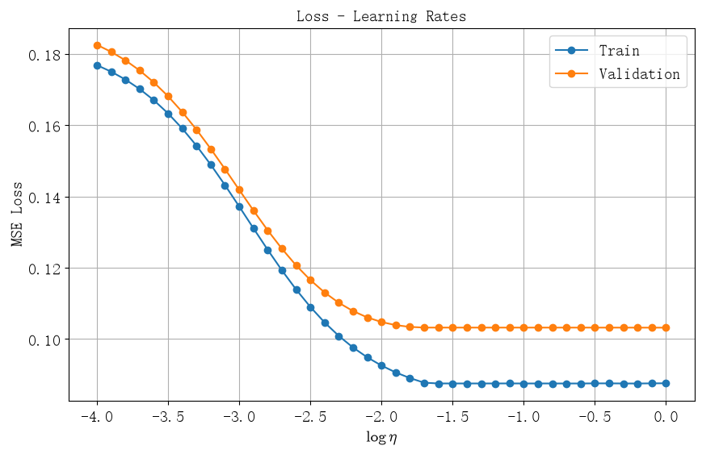

从结果可以看到, MSE 与前面的 BCE 具有相似的学习率变化趋势. 当学习率较小时, 在固定的 $2000$ 个 Epoch 内模型尚未充分收敛, 因而 Train Loss 和 Val Loss 均较大. 随着学习率增大, Loss 逐渐下降, 并在较大学习率区域进入近似平台.

因此, 当前学习率扫描反映出的主要差异是收敛速度. 当学习率已经足够大时, 在相同训练轮数下继续增加学习率并不能明显降低最终 Loss. 为兼顾收敛速度和训练稳定性, 后续与 BCE 相同取 $\eta=1$ 进行多项式阶数调优.

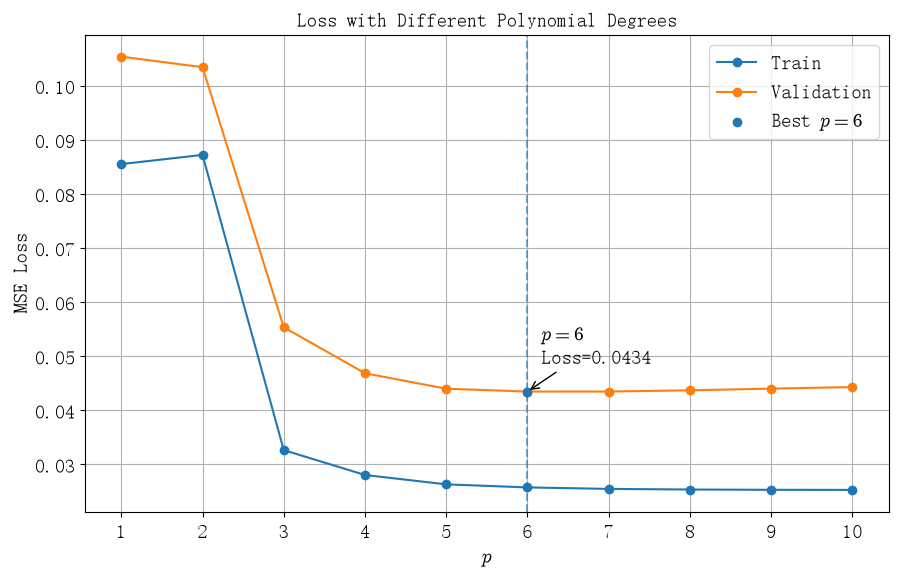

MSE 下模型复杂度对 Loss 的影响与 BCE 基本一致. 当 $p=1,2$ 时, 多项式特征不足以描述 `make_moons` 数据的非线性分类边界, 因而 Train Loss 和 Val Loss 均较高. 从 $p=3$ 开始, 随着模型表达能力增强, 两者均明显下降.

Val Loss 随 $p$ 增大先下降后趋于上升, 并在 $p=6$ 处取得最小值

因此 MSE 与 BCE 最终都选择 $p=6$. 这说明在当前数据和划分下, 两种损失函数对于合适模型复杂度给出了相同的判断.

最优时的分类边界为：

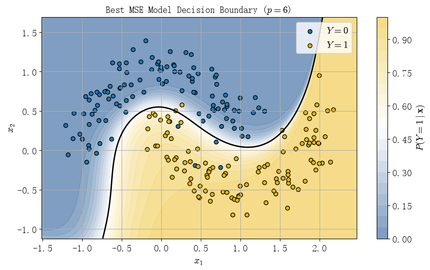

MSE 最优模型同样选择 $p=6$, 能够形成与两个月牙整体结构相符的非线性分类边界.

与 BCE 相比, 两种模型得到的整体边界形状非常接近, 但在部分区域仍存在一定差异. MSE 在中部和右部的 $P(Y=1\mid\mathbf x)=0.5$ 边界略高, 因而局部预测为 $Y=1$ 的区域略有扩大.

这说明即使使用完全相同的多项式特征和分类阈值, 不同损失函数仍可能得到不同的概率函数和分类边界.

### 对比分析

分别对 BCE 和 MSE 下训练的模型计算混淆矩阵并计算四个值，有：

|  | Accuracy | Precision | Recall | F1 |
| --- | --- | --- | --- | --- |
| Train | 0.977273 | 0.956522 | 1.000000 | 0.977778 |
| Val | 0.954545 | 1.000000 | 0.909091 | 0.952381 |
| Test | 0.977273 | 1.000000 | 0.954545 | 0.976744 |
| All | 0.972727 | 0.972727 | 0.972727 | 0.972727 |

|  | Accuracy | Precision | Recall | F1 |
| --- | --- | --- | --- | --- |
| Train | 0.977273 | 0.956522 | 1.000000 | 0.977778 |
| Val | 0.931818 | 0.952381 | 0.909091 | 0.930233 |
| Test | 0.977273 | 1.000000 | 0.954545 | 0.976744 |
| All | 0.968182 | 0.963964 | 0.972727 | 0.968326 |

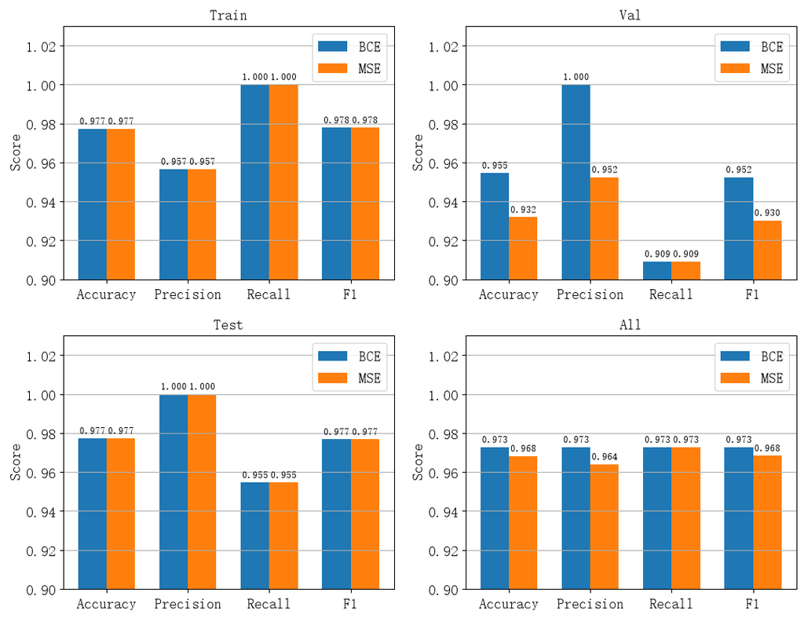

BCE 和 MSE 在 Train 上得到完全相同的分类结果, Accuracy 均为 $0.9773$. 在 Test 上两种模型也得到完全相同的结果, 均只有 1 个正类样本被误判, Accuracy 为 $0.9773$.

两种损失函数的差异主要出现在 Val. 在全部 220 个样本上, BCE 的 Accuracy 为 $0.9727$, MSE 为 $0.9682$, 二者只相差 1 个分类错误样本.

因此在当前数据集上, BCE 和 MSE 最终得到的硬分类性能非常接近, BCE 略优于 MSE.

### 理论解释

设 Logistic 回归的线性输出和预测概率分别为

$$ z=\mathbf w^\mathsf T\boldsymbol\phi(\mathbf x)+b $$

$$ \hat y=\sigma(z) $$

对于 BCE, 可以得到

$$ \frac{\partial J_{\mathrm{BCE}}}{\partial z}= \hat y-y $$

而对于 MSE,

$$ J_{\mathrm{MSE}}= (\hat y-y)^2 $$

因此

$$ \frac{\partial J_{\mathrm{MSE}}}{\partial z}= 2(\hat y-y)\hat y(1-\hat y) $$

两者之间最重要的区别在于 MSE 梯度额外包含

$$ \hat y(1-\hat y) $$

由于

$$ 0<\hat y(1-\hat y)\le\frac14 $$

当 Sigmoid 输出接近 $0$ 或 $1$ 时, 这一项趋近于 $0$. 因此 MSE 在 Sigmoid 的饱和区域中容易产生较小的梯度.

这解释了为什么 MSE 虽然同样能够用于训练当前 Logistic 模型, 但优化性质弱于 BCE.

## 随机权重初始化对结果的影响

随机权重会改变梯度下降的起点. 为单独研究这一因素, 保持数据划分、多项式阶数、学习率和训练轮数不变, 只改变初始参数.

生成 $100$ 组相互独立的随机初始参数

$$ w_j\sim\mathcal N(0,1^2),\qquad b\sim\mathcal N(0,1^2) $$

分别进行完整训练.

由于我们的权重是一个高维向量，这里我们通过其模长来表征其分布.

### BCE 下随机权重影响

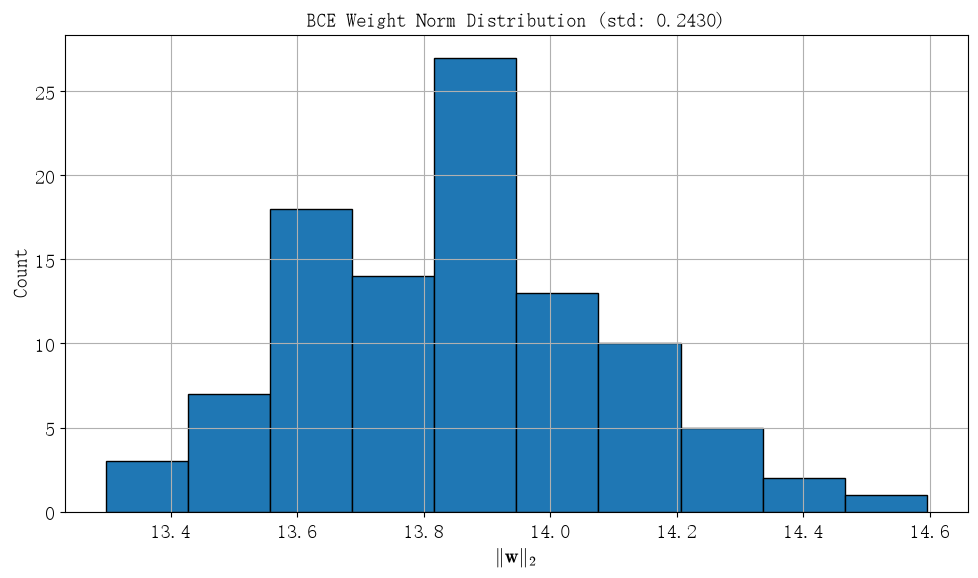

从 BCE 的结果可以看到, $100$ 组随机初始化得到的最终权重并不完全相同. 权重范数主要分布在 $13.30\sim14.60$ 之间, 标准差约为

$$ \sigma_{\|\mathbf w\|}\approx0.2430 $$

说明不同初始参数会使最终参数产生一定变化, 但权重整体尺度仍然较为集中.

### MSE 下随机权重影响

对 MSE 进行相同操作，有：

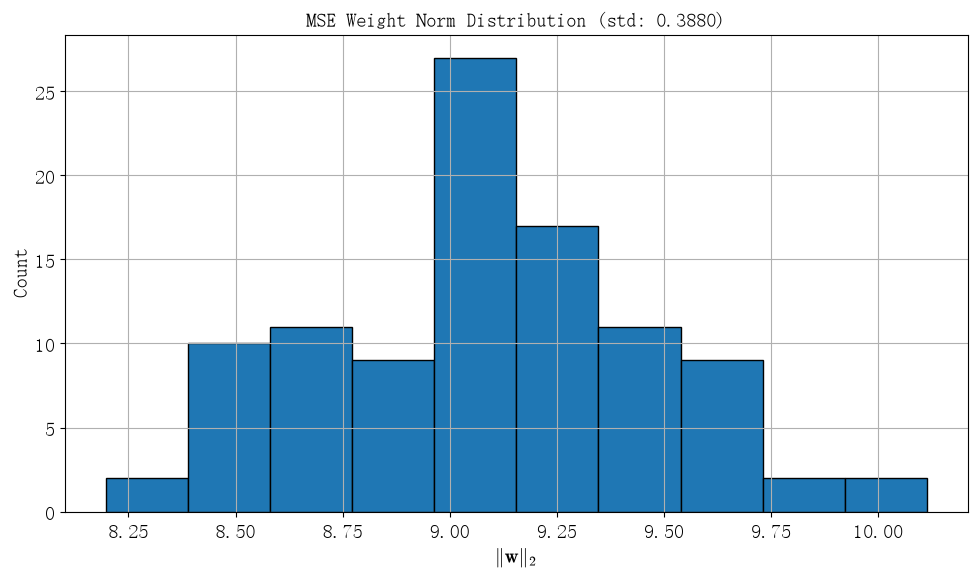

MSE 的最终权重范数约分布在 $8.20\sim10.11$

之间, 标准差约为

$$ \sigma_{\|\mathbf w\|}\approx0.3880 $$

其离散程度大于 BCE, 表明 MSE 最终参数对随机初始化表现出更明显的敏感性.

### 理论解释

对于固定的特征映射, BCE Logistic 回归关于参数的 Hessian 可以写成

$$ H= \frac{1}{m} \Phi^\mathsf T R\Phi $$

其中

$$ R= \operatorname{diag} \left[\hat y_i(1-\hat y_i)\right] $$

因此是凸优化问题. 在学习率合适且训练充分的情况下, 不同随机初值通常会收敛到相同的全局最优区域, 因而初始参数对最终结果的影响较小.

对于 MSE,

$$ \frac{\partial J_{\mathrm{MSE}}}{\partial z} =2(\hat y-y)\hat y(1-\hat y) $$

其目标函数不再具有 BCE Logistic 回归相同的凸性. 因此从理论上看, MSE 更可能受到初始参数的影响.

## 结论

本次实验使用 Logistic 回归对 `make_moons` 二分类数据集进行分类. 在原始二维输入特征的基础上构造多项式特征, 使用梯度下降进行模型训练, 并进一步研究学习率、多项式阶数、BCE 与 MSE 损失函数以及随机权重初始化对模型的影响. 得到如下结论：

- 原始 `make_moons` 数据具有明显的非线性分类边界. 仅使用低阶特征时模型表达能力不足. 通过加入满足 $1\le a+b\le p$ 的多项式特征, Logistic 回归可以形成非线性的分类边界.
- 对学习率 $\eta=10^{-4}\sim1$ 进行扫描后发现, 当学习率较小时, 固定 $2000$ 个 Epoch 内模型尚未充分收敛. 当 $\eta\gtrsim10^{-2}$ 后, 最优 Validation Loss 基本进入平台区. 本实验最终取 $\eta=1$ 进行后续训练.
- 使用 BCE 训练得到的最终模型在 Test 中仅错误分类 1 个样本. 其分类指标为

$$ \mathrm{Accuracy}=0.9773 $$

$$ \mathrm{Precision}=1.0000 $$

$$ \mathrm{Recall}=0.9545 $$

$$ F_1=0.9767 $$

在全部 $220$ 个样本中共有 $6$ 个样本分类错误, Overall Accuracy 为 $0.9727$. 最终分类边界能够较好地描述两个月牙之间的非线性分界.

- BCE 和 MSE 最终都选择 $p=6$, 并得到较为接近的分类边界. 两者最终硬分类性能整体非常接近，但 BCE 在实验中更优
- 进行 $100$ 组随机初始化实验后发现, BCE 和 MSE 得到的最终参数都会随初始条件发生一定变化. BCE 的权重范数标准差约为 $0.2430$，而 MSE 为 $0.3880$. 说明 MSE 的最终参数对随机初始化表现出更大的离散程度.

综合来看, 对当前 `make_moons` 数据集, 多项式特征 Logistic 回归能够实现较好的非线性分类. 本实验最终选取

$$ p=6,\qquad\eta=1 $$

并采用 BCE 作为损失函数.

## 参考资料以及 AI 使用说明

- 背景补充部分个人写出大体大纲，使用 GPT 6 Astra 生成并进行人工核验和修改.
- 代码编写使用 Deepseek V4 Flash FIM 模式进行补全和生成（尤其是绘图相关函数，基本是直接生成），经过人工核验和运行验证.
- 扫参函数由 Deepseek V4 Flash 生成，经过人工核验和运行验证.
- 文本和公式编写使用 Deepseek V4 Flash FIM 模式进行生成和补全，经过人工核验和修改.

## 致谢

暂无.

## 附一：问题

1. 本实验中 BCE Logistic 回归的目标函数是凸函数, 理论上不存在彼此独立的局部极小值. 但是不同随机初始化最终仍然得到略有不同的权重范数. 这种差异主要来自有限的训练 Epoch 还是参数空间中存在近似平坦方向？
2. 理论上使用 MSE 后不是一个凸优化问题，但是就结果来看其权重仍旧收敛到一个相似的区域，这是否是因为我们随机的范围不够大导致的？

## 附二：学习心得

暂无